# PHYS 210 Day 12

### 2026 - 10 - 26

Agenda:

1. Announcements: **Test 3 (Days 09–10 + dictionaries): open now, through Fri Oct 30** · Homework 11 and Preclass 12 were due today · Test 4 (Mon Nov 16 – Fri Nov 20) covers Days 11–12 only (solve_ivp) · Monte-Carlo 2 moves to Mon Nov 23 and onto Test 5
2. Reading 12 recap, Q&A and polling questions: systems of ODEs and orbits
3. **Project A is assigned today**
4. Group Worksheet 12

## Reading recap, Q&A and polling questions

From `[h, v]` to `[x, y, vx, vy]`: a force toward a centre, two physics checks, and a mistake the unit circle cannot show

## Reading recap: from `[h, v]` to `[x, y, vx, vy]`

- Motion in a plane: one Newton equation for $x$, one for $y$. Each becomes two first-order equations: a **system of four** $$\frac{dx}{dt} = v_x, \qquad \frac{dy}{dt} = v_y, \qquad \frac{dv_x}{dt} = a_x, \qquad \frac{dv_y}{dt} = a_y$$

```
def derivs(t, state):
    x, y, vx, vy = state
    ...                            # compute ax and ay
    return [vx, vy, ax, ay]        # same order as the state
```

- `solve_ivp()` does not care how long the state is
- With drag, $a_x$ depends on $v_y$ (through the speed): x and y cannot be solved separately, `solve_ivp()` solves all four together

### Reading a 2D solution: the rows of `sol.y`, and the path

- `sol.y` has one row per state variable, in the order of `state0`: `sol.y[0]` = $x$, `sol.y[1]` = $y$, `sol.y[2]` = $v_x$, `sol.y[3]` = $v_y$
- One column per time: the shape is `(4, len(sol.t))`
- The path of the ball: `plt.plot(sol.y[0], sol.y[1])`, y versus x. Time is not on the graph
- `sol.y` is the whole state. The position $y(t)$ is `sol.y[1]`, the second row
- A terminal event at the ground: the landing time is in `sol.t_events[0]`, the state at landing in `sol.y_events[0][0]`, so the landing point is `sol.y_events[0][0][0]`

### A force toward a centre: why $-x/r^3$

Gravity has magnitude $GM/r^2$ and points toward the star. The unit vector away from the star is $\hat r = (x, y)/r$: $$\vec a = -\frac{GM}{r^2}\,\hat r = -\frac{GM}{r^2}\,\frac{(x,\ y)}{r} \qquad\Longrightarrow\qquad a_x = -\frac{GM\,x}{r^3}, \qquad a_y = -\frac{GM\,y}{r^3}$$

```
r = np.sqrt(x**2 + y**2)
ax = -x / r**3          # GM = 1
ay = -y / r**3
```

- $r^3$ is not a new force law: $r^2$ from the magnitude, one more $r$ from the unit vector. The force still falls off as $1/r^2$
- Check both parts: the magnitude $|\vec a| = GM/r^2$, and the direction along $-(x, y)$
- Coulomb's law (Electric Field Hockey) has the same $1/r^2$ form, so the same $r^3$
- Common mistake: `-x / r**2`. At $r = 1$ it gives the same numbers as `-x / r**3`, so a test on the unit circle cannot show it

### Is the orbit right? Two physics checks

1. **The orbit closes**: a bound orbit is a circle or an ellipse. After one orbit the planet is back where it started
2. **The energy stays constant**: $E = \tfrac12 (v_x^2 + v_y^2) - GM/r$ is the same at every time

Three orbits from the circular start `[1, 0, 0, 1]` (Preclass 12.3):

|  | $r$ stays between | end of the third orbit | $E$ changes by |
| --- | --- | --- | --- |
| default settings | 0.8487 and 1.0000 | x = −0.64, y = 0.56 | 8.6e-02 |

- A "circle" that spirals inward is **integration error**

**Poll Q1:** The state is `[x, y, vx, vy]`. What does this print?

```python
import numpy as np
from scipy.integrate import solve_ivp

def derivs(t, state):
    x, y, vx, vy = state
    return [vx, vy, 0, -9.81]

sol = solve_ivp(derivs, [0, 1], [0, 0, 3, 4], t_eval=[0, 0.5, 1])
print(np.round(sol.y[2], 2))
```

A) `[0. 1.5 3. ]`  
B) `[ 0. 0.77 -0.9 ]`  
C) `[3. 3. 3.]`  
D) `[ 4. -0.9 -5.81]`

**Poll Q2:** A planet at $x = 2$, $y = 0$, with $GM = 1$. What does this print?

```python
import numpy as np

x, y = 2, 0
r = np.sqrt(x**2 + y**2)
ax_wrong = -x / r**2
ax = -x / r**3
print(ax_wrong, ax)
```

A) `-0.25 -0.25`  
B) `-0.5 -0.25`  
C) `-1.0 -0.5`  
D) `-0.5 -0.125`

**Poll Q3:** Three orbits from `[1, 0, 0, 1]` with the default tolerances: the "circle" spirals inward and the energy changes by 0.086. Which change makes the energy constant?

A) `t_eval=np.linspace(0, 6*np.pi, 6001)` instead of 601 points  
B) `plt.axis('equal')` before `plt.show()`  
C) `rtol=1e-8, atol=1e-8` in the `solve_ivp()` call  
D) None: the energy of an orbit changes slowly

**Poll Q4:** Someone wrote `-x / r**2` instead of `-x / r**3` and tested it on the circle `[1, 0, 0, 1]`, with `rtol=1e-8, atol=1e-8`: the radius stays at 1. Which test shows the mistake?

A) the same start for 100 orbits  
B) the same start with `rtol=1e-12, atol=1e-12`  
C) the same circle, started on the y-axis: `[0, 1, -1, 0]`  
D) a circle of radius 2 for real gravity: `[2, 0, 0, 1/np.sqrt(2)]`

## Project A is assigned today

Your own investigation with `solve_ivp`. Pick one of three topics:

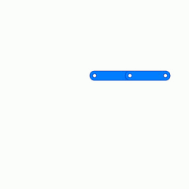

**The double pendulum**

For small swings the motion is regular. Start it high and it seems to have a mind of its own

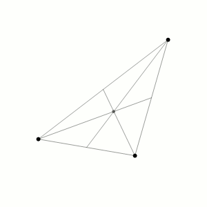

**Three suns and a planet**

Add two more suns to Kepler's problem and no formula can tell you what happens. Can a planet survive there?

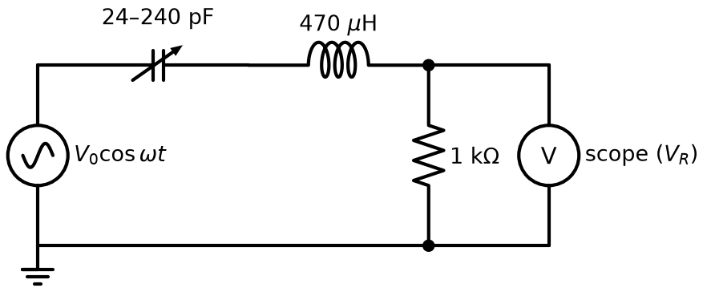

**The driven LRC circuit**

The circuit of the PHYS 219 lab. Would you measure the textbook resonance on the lab bench?

- **20 %** of your course mark. **Individual**: discuss ideas with classmates, but your code and your brief are your own
- Coming to Canvas: the three project notebooks and the page **Project A: how you are assessed**

Animations from Wikimedia Commons: [“Double pendulum simulation”](https://commons.wikimedia.org/wiki/File:Double_pendulum_simulation.gif) by Zvika (CC0, resized) · [“Three-body Problem Animation with COM”](https://commons.wikimedia.org/wiki/File:Three-body_Problem_Animation_with_COM.gif) by Dnttllthmmnm, [CC BY-SA 4.0](https://creativecommons.org/licenses/by-sa/4.0/)

### Homework 10 + Preclass 11: what the submissions showed

Almost all of you got "Task 3 passed" and the self-assessment keys. Three things the checks did not catch:

- **dR settles, it does not shrink:** dR = 2.0 Ω for every N from 500 to 10⁶. It is the spread of R, set by dV and dI. What shrinks like 1/√N is the uncertainty of the mean R: dR/√N = 0.029 Ω at N = 5000, 0.002 Ω at N = 10⁶
- **The spread comes from your samples:** `z_samples = np.log(x_samples) + y_samples**2`, then `dz_mc = np.std(z_samples, ddof=1)`. The calculus formula, or `np.random.normal(z_calc, dz_calc, N)`, also passes: the test compares with `dz_calc`, so it cannot tell
- **`sol.y` holds every state variable:** `np.max(solution.y)` prints `10.00`, the start speed, not a height. Heights only: `np.max(solution.y[0])` prints `5.10` (= v₀²/2g). Today the state is `[x, y, vx, vy]`: 4 rows, and the path is `plt.plot(sol.y[0], sol.y[1])`

# The rest of today, and before you leave

- **Group Worksheet 12** (orbit experiments: break the circle, the energy check with tighter tolerances, and escape): link on Canvas; one driver per task, swap each task; Tasks 1–3 required, checkpoint with a TA after Task 3
- **Homework 12** (Euler vs RK4 vs `solve_ivp`: the Euler error against `dt`, then all three on a spring) due Wed Oct 28, 9:00 am. **Restart Kernel and Run All Cells before you export**
- **Project A: pick your topic** (a one-question survey on Canvas: which of the three topics?) due Wed Oct 28, 9:00 am
- **Wednesday:** Project A studio, the whole class
- **Test 3** (Days 09–10 + dictionaries): open now, through Fri Oct 30 · Practice Test 3 is live